# Cash Liquidity Forecasting for UCITS portfolios

## Predictive Analytics with ARIMA, Random Forest & XGBoost

### Created by Karoly Takacs - 2025

> “All models are wrong, but some are useful.”  
> – George E. P. Box
- I. Introduction
- II. Importing packages, Loading data & Exploratory data analysis
- III. Model building
- IV. Evaluation
- V. Model Distillation
- VI. Conclusion

# I. Introduction

The ability to accurately forecast liquidity within portfolios is a core pillar of modern risk management and regulatory compliance. High-frequency liquidity prediction models empower asset managers to optimize cash allocation, reduce costly drawdowns, and maintain operational flexibility—directly contributing to enhanced fund performance and client confidence. Moreover, the development of robust, explainable models enables more transparent portfolio oversight, more reliable stress-testing, and clearer communication of liquidity risk.

The methodologies and results presented in this project are designed to anticipate potential liquidity trends by combining advanced machine learning with interpretable analytics. Due to the proprietary nature and confidentiality constraints surrounding individual fund-level data, the subsequent academic analysis focuses on aggregated model performance and explainability. Results are examined in detail through synthetic portfolios grouped by major asset classes—namely equities, fixed income, and multi-asset funds. This aggregation ensures that all technical findings can be scrutinized, benchmarked, and interpreted without compromising sensitive commercial information.

### Technical Methodology

The empirical investigation centers on the liquidity dynamics of portfolios regulated under the UCITS (Undertakings for Collective Investment in Transferable Securities) framework—a set of European Union directives that set rigorous standards for liquidity, diversification, and investor protection. UCITS portfolios typically encompass a diversified set of assets across geographies and sectors, and are subject to daily liquidity and transparency requirements.

Models are evaluated through rigorous out-of-sample rolling validation, with performance metrics including mean absolute error (MAE), root mean square error (RMSE), mean absolute percentage error (MAPE), and R². Aggregation at the asset class level not only protects confidentiality but also enables the analysis of systemic liquidity risk factors and the robustness of model insights across different segments of the fund universe.

# II. Importing packages, Loading data & Exploratory data analysis

```python
# Importing necessary libraries

## Data Manipulation and Analysis
import pandas as pd
import numpy as np

## Visualization
import matplotlib.pyplot as plt
import matplotlib.ticker as ticker
import seaborn as sns
from matplotlib.colors import LinearSegmentedColormap

## Time Series Modeling
from statsmodels.tsa.arima.model import ARIMA

## Machine Learning Models
from sklearn.ensemble import RandomForestRegressor
from xgboost import XGBRegressor
from sklearn.linear_model import LinearRegression

## Metrics for Model Evaluation
from sklearn.metrics import (
    mean_absolute_error,
    mean_squared_error,
    mean_absolute_percentage_error,
    median_absolute_error,
    r2_score,
    explained_variance_score
)

## SHAP for Model Interpretability
import shap

## Parallel Processing
from joblib import Parallel, delayed

## Warnings Management
import warnings
warnings.filterwarnings("ignore")

## Display Utilities
from IPython.display import display, HTML

## Widgets for Interactive Visualizations
import ipywidgets as widgets
```

```python
# Load the data into a DataFrame
df = pd.read_csv('data.csv', sep=";")

# Display the DataFrame info
df.info()
```

```
<class 'pandas.core.frame.DataFrame'>
RangeIndex: 151292 entries, 0 to 151291
Data columns (total 17 columns):
 #   Column       Non-Null Count   Dtype
---  ------       --------------   -----
 0                151292 non-null  int64
 1   DCLG_ID      151292 non-null  object
 2   FUND_NAME    151292 non-null  object
 3   F_ID         151292 non-null  int64
 4   REG_RM       151292 non-null  object
 5   ACLASS       151292 non-null  object
 6   VAR_RATIO    151292 non-null  float64
 7   IMP_FLAG     140628 non-null  float64
 8   SRC_FLAG     140628 non-null  float64
 9   RF_ID        140628 non-null  float64
 10  NODE_ID      140628 non-null  float64
 11  DATE_C       151292 non-null  object
 12  F_ID.1       151292 non-null  int64
 13  RIA_NODE     151292 non-null  object
 14  DTYPE_DET    151292 non-null  object
 15  RISK_DRIVER  7310 non-null    object
 16  CMNT         7310 non-null    object
dtypes: float64(5), int64(3), object(9)
memory usage: 19.6+ MB
```

```python
# Get unique values from the DTYPE_DET column
unique_dtype_det = df['DTYPE_DET'].unique()
unique_dtype_det
```

```
array(['Liquidity Profile CASH', 'SR acc', 'UCITS - Commitment',
       'Liquidity Profile incl. SD [Ptf] >1Y', 'TCOST_CUS30_WATE_TD_1D',
       'TCOST_TOTAL_WATE_TD_1D', 'Liquidity Profile incl. SD [Ptf] 1Q',
       'Liquidity Profile incl. SD [Ptf] 1Y',
       'Liquidity Profile incl. SD [Ptf] 1M', 'VaR 99% 1Y PTF',
       'cVaR 99% 1Y PTF', 'Liquidity Profile incl. SD [Ptf] 1S',
       'VaR 99% 1Y REF', 'cVaR 99% 1Y REF',
       'Liquidity Profile incl. SD [Ptf] 1W', 'Ptf PV'], dtype=object)
```

## Description of Portfolio Liquidity and Risk Variables

[output not shown]

```python
# Strip whitespace from column names
df.columns = df.columns.str.strip()

# Convert DATE_C from DD.MM.YYYY to ISO format (YYYY-MM-DD)
df['DATE_C'] = pd.to_datetime(df['DATE_C'], format='%d.%m.%Y')

# Convert relevant columns to numeric, forcing errors to NaN
df['VAR_RATIO'] = pd.to_numeric(df['VAR_RATIO'], errors='coerce')

# Pivot the DataFrame to reshape it
pivot_df = (
    df.pivot_table(
        index=['DCLG_ID', 'FUND_NAME', 'ACLASS', 'DATE_C'],  # Group by these columns
        columns=['DTYPE_DET'],                               # Pivot on these columns
        values='VAR_RATIO',                                  # Values to aggregate
        aggfunc='mean'                                       # Aggregation function
    )
    .reset_index()   # Reset the index for flat DataFrame
    .fillna(0)       # Fill NaN values with 0 or any other value as needed
)

# Display the new DataFrame info
pivot_df.info()
```

```
<class 'pandas.core.frame.DataFrame'>
RangeIndex: 11081 entries, 0 to 11080
Data columns (total 20 columns):
 #   Column                                Non-Null Count  Dtype
---  ------                                --------------  -----
 0   DCLG_ID                               11081 non-null  object
 1   FUND_NAME                             11081 non-null  object
 2   ACLASS                                11081 non-null  object
 3   DATE_C                                11081 non-null  datetime64[ns]
 4   Liquidity Profile CASH                11081 non-null  float64
 5   Liquidity Profile incl. SD [Ptf] 1M   11081 non-null  float64
 6   Liquidity Profile incl. SD [Ptf] 1Q   11081 non-null  float64
 7   Liquidity Profile incl. SD [Ptf] 1S   11081 non-null  float64
 8   Liquidity Profile incl. SD [Ptf] 1W   11081 non-null  float64
 9   Liquidity Profile incl. SD [Ptf] 1Y   11081 non-null  float64
 10  Liquidity Profile incl. SD [Ptf] >1Y  11081 non-null  float64
 11  Ptf PV                                11081 non-null  float64
 12  SR acc                                11081 non-null  float64
 13  TCOST_CUS30_WATE_TD_1D                11081 non-null  float64
 14  TCOST_TOTAL_WATE_TD_1D                11081 non-null  float64
 15  UCITS - Commitment                    11081 non-null  float64
 16  VaR 99% 1Y PTF                        11081 non-null  float64
 17  VaR 99% 1Y REF                        11081 non-null  float64
 18  cVaR 99% 1Y PTF                       11081 non-null  float64
 19  cVaR 99% 1Y REF                       11081 non-null  float64
dtypes: datetime64[ns](1), float64(16), object(3)
memory usage: 1.7+ MB
```

```python
# Read macro_data and convert to datetime (update 'Date' col-name if needed!)
macro_data = pd.read_csv('macroeconomic_indicators_2024.csv', sep=';')

# Display the macro_data info
macro_data.info()
```

```
<class 'pandas.core.frame.DataFrame'>
RangeIndex: 366 entries, 0 to 365
Data columns (total 14 columns):
 #   Column                          Non-Null Count  Dtype
---  ------                          --------------  -----
 0   Date                            366 non-null    object
 1   US CPI                          366 non-null    float64
 2   US Unemployment Rate            366 non-null    float64
 3   US Fed Funds Rate               366 non-null    float64
 4   US GDP                          366 non-null    float64
 5   US Retail Sales                 366 non-null    int64
 6   US Consumer Confidence          366 non-null    float64
 7   US Industrial Production        366 non-null    float64
 8   US VIX                          366 non-null    float64
 9   US High Yield Credit Spread     366 non-null    float64
 10  EU HICP                         366 non-null    float64
 11  EU GDP                          366 non-null    float64
 12  EU liquidity-absorbing factors  366 non-null    int64
 13  EU interest rate                366 non-null    float64
dtypes: float64(11), int64(2), object(1)
memory usage: 40.2+ KB
```

## Description of Macroeconomic and Financial Variables

| Variable | Description |
| --- | --- |
| **Date** | Date of observation (calendar date for the data row) |
| **US CPI** | US Consumer Price Index (inflation measure, % YoY or monthly change) |
| **US Unemployment Rate** | US Unemployment Rate (% of labor force unemployed) |
| **US Fed Funds Rate** | US Federal Funds Rate (key short-term policy interest rate set by the Federal Reserve, %) |
| **US GDP** | US Gross Domestic Product (economic output, usually real GDP, level or % change) |
| **US Retail Sales** | US Retail Sales (indicator of consumer spending, can be level or % change) |
| **US Consumer Confidence** | US Consumer Confidence Index (survey-based gauge of economic optimism/pessimism) |
| **US Industrial Production** | US Industrial Production Index (gauge of real production output of factories/mines/utilities) |
| **US VIX** | CBOE Volatility Index ("VIX", measure of implied equity market volatility) |
| **US High Yield Credit Spread** | Difference in yield between US high-yield (junk) bonds and comparable Treasuries (basis points, bps) |
| **EU HICP** | Euro Area Harmonized Index of Consumer Prices (inflation, % YoY or monthly change) |
| **EU GDP** | Euro Area Gross Domestic Product (economic output, level or % change) |
| **EU liquidity-absorbing factors** | European Central Bank (ECB) measures to absorb excess liquidity (e.g., deposits, operations) |
| **EU interest rate** | Key ECB policy interest rate (e.g., main refinancing rate, %) |

```python
# Convert the 'Date' column to datetime format
macro_data['Date'] = pd.to_datetime(macro_data['Date'], dayfirst=True)

# Merge pivot_df (left) with macro_data (right) on date
merged = pd.merge(
    pivot_df,
    macro_data,
    left_on='DATE_C',
    right_on='Date',
    how='left',    # or 'inner' if you want to drop rows with no macro data for that date!
)

# print the shape of the merged DataFrame
print(f"DataFrame merged has {merged.shape[0]} rows and {merged.shape[1]} columns.")
```

```
DataFrame merged has 11081 rows and 34 columns.
```

```python
# Display merged dataframe info
merged.info()
```

```
<class 'pandas.core.frame.DataFrame'>
RangeIndex: 11081 entries, 0 to 11080
Data columns (total 34 columns):
 #   Column                                Non-Null Count  Dtype
---  ------                                --------------  -----
 0   DCLG_ID                               11081 non-null  object
 1   FUND_NAME                             11081 non-null  object
 2   ACLASS                                11081 non-null  object
 3   DATE_C                                11081 non-null  datetime64[ns]
 4   Liquidity Profile CASH                11081 non-null  float64
 5   Liquidity Profile incl. SD [Ptf] 1M   11081 non-null  float64
 6   Liquidity Profile incl. SD [Ptf] 1Q   11081 non-null  float64
 7   Liquidity Profile incl. SD [Ptf] 1S   11081 non-null  float64
 8   Liquidity Profile incl. SD [Ptf] 1W   11081 non-null  float64
 9   Liquidity Profile incl. SD [Ptf] 1Y   11081 non-null  float64
```

[output cut: 26 more lines]

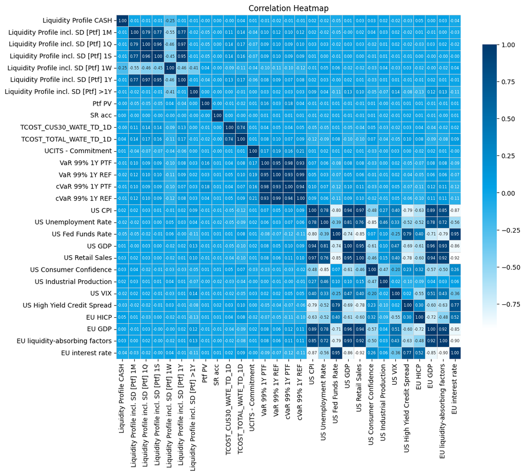

```python
# Select only numeric columns for correlation
numeric_df = merged.select_dtypes(include=['number'])

# Calculate the correlation matrix
correlation_matrix = numeric_df.corr()

# Define a custom Amundi-style colormap (white -> #00A1E5 -> #003A6E)
amundi_cmap = LinearSegmentedColormap.from_list(
    "amundi",
    ["#ffffff", "#00A1E5", "#003A6E"],
    N=256
)

# Set up the matplotlib figure
plt.figure(figsize=(12, 10))

# Create a heatmape
sns.heatmap(
    correlation_matrix,
    annot=True,
    fmt=".2f",
    cmap=amundi_cmap,
    square=True,
    cbar_kws={"shrink": .8},
    linewidths=0.5,
    linecolor='lightgrey',
    annot_kws={"size": 6}
)

# Set the title
plt.title('Correlation Heatmap')
# Show the plot
plt.show()

# Group by ACLASS and count unique FUND_NAME entries
fund_name_aclass_unique_counts = merged.groupby('ACLASS')['FUND_NAME'].nunique().reset_index(name='Unique_Fund_Count')
```

```python
# Initialize a dictionary to store cleaned data
cleaned_data = {}

# Get unique DCLG_ID values from merged
unique_funds = merged['DCLG_ID'].unique()

# Define liquidity-related columns
liquidity_cols = [
    'Liquidity Profile CASH',
    'Liquidity Profile incl. SD [Ptf] 1M',
    'Liquidity Profile incl. SD [Ptf] 1Q',
    'Liquidity Profile incl. SD [Ptf] 1S',
    'Liquidity Profile incl. SD [Ptf] 1W',
    'Liquidity Profile incl. SD [Ptf] 1Y',
    'Liquidity Profile incl. SD [Ptf] >1Y'
]

# Tolerance level around 1.0
tolerance = 0.001

# Loop through each fund
for fund in unique_funds:
    fund_df = merged[merged['DCLG_ID'] == fund].copy()

    # Drop duplicates
    fund_df.drop_duplicates(inplace=True)

    # Replace 0s and outliers with NaN
    for col in liquidity_cols:
        threshold = fund_df[col].quantile(0.99)
        mask = (fund_df[col] == 0) | (fund_df[col] > threshold)
        fund_df.loc[mask, col] = np.nan

    # Fill missing with the mean of the next 7 values (including the current one)
    fund_df[liquidity_cols] = fund_df[liquidity_cols].fillna(
        fund_df[liquidity_cols].shift(-1).rolling(window=7, min_periods=1).mean()
)

    # Recalculate liquidity sum
    fund_df['liquidity_sum'] = fund_df[liquidity_cols].sum(axis=1)

    # Normalize rows where liquidity sum ≠ 1 (within tolerance)
    def normalize_row(row):
        if abs(row['liquidity_sum'] - 1) > tolerance:
            nonzero_cols = [col for col in liquidity_cols if row[col] > 0]
            total = row[nonzero_cols].sum()
            if total > 0:
                for col in nonzero_cols:
                    row[col] = row[col] / total
                row['liquidity_sum'] = 1.0
        return row

    fund_df = fund_df.apply(normalize_row, axis=1)

    # Save to dictionary
    cleaned_data[fund] = fund_df
```

# III. Modeling_Building

## **ARIMA (Autoregressive integrated moving average), Random Forest & XGBoost**

This chapter outlines a series of utility functions and a comprehensive modeling approach for forecasting fund performance using time series data. The key components include:

## 1. Utility Functions

- **`build_fund_name_map`**: Creates a mapping of fund names to their respective IDs from cleaned data.
- **`calculate_metrics`**: Computes various performance metrics (e.g., MAE, RMSE, R²) to evaluate model predictions against actual values.
- **`extended_lag_features`**:
  - Generates lagged features, differences, and rolling statistics for specified columns in the dataset to enhance predictive modeling.
  - For each specified column, it creates:
    - Lagged values for specified time lags (0, 1, 2, 3, 5, 7, 14 days).
    - Differences between current and lagged values.
    - A 7-day rolling mean.
    - A 7-day rolling standard deviation.
    - A 7-day exponential moving average (EMA).
- **`impute_with_special_forward_rolling_mean`**: Handles missing values by applying a forward rolling mean strategy.
- **`sanitize_feature_names`**: Cleans feature names for better readability.
- **`make_business_friendly_name`**: Converts technical feature names into more understandable business-friendly formats.

## 2. Main Results Structure

- Initializes a results dictionary to store metrics and curves for different forecasting models (ARIMA, Random Forest, and XGBoost).

## 3. Fund-Level Rolling Forecast Modeling

- The **`process_fund`** function implements a rolling forecast strategy for each fund, utilizing ARIMA for time series forecasting and Random Forest and XGBoost for regression tasks.
- The function processes the data by filtering for relevant columns, creating features, and splitting the data into training and testing sets.
- It performs rolling predictions for each model, calculates metrics, and captures feature importances and SHAP values for interpretability.

## 4. Parallel Processing

- The chapter concludes with a parallel execution of the `process_fund` function across multiple funds, aggregating results into the predefined structure for further analysis.

Overall, this chapter provides a robust framework for forecasting fund performance, leveraging advanced statistical and machine learning techniques to derive insights from financial data.

```python
# ---------- Utility Functions ----------
def build_fund_name_map(cleaned_data):
   return {str(df["FUND_NAME"].iloc[0]) if "FUND_NAME" in df.columns else str(fid): fid
           for fid, df in cleaned_data.items()}
def calculate_metrics(y_true, y_pred):
   df = pd.DataFrame({'y_true': y_true, 'y_pred': y_pred}).dropna()
   if len(df) == 0:
       return {k: np.nan for k in ['MAE', 'RMSE', 'MAPE', 'Median_AE', 'R2', 'Bias', 'Explained_Var']}
   return {
       'MAE': mean_absolute_error(df['y_true'], df['y_pred']),
       'RMSE': np.sqrt(mean_squared_error(df['y_true'], df['y_pred'])),
       'MAPE': mean_absolute_percentage_error(df['y_true'], df['y_pred']),
       'Median_AE': median_absolute_error(df['y_true'], df['y_pred']),
       'R2': r2_score(df['y_true'], df['y_pred']),
       'Bias': np.mean(df['y_pred'] - df['y_true']),
       'Explained_Var': explained_variance_score(df['y_true'], df['y_pred']),
   }
def extended_lag_features(df, cols):
   for col in cols:
       for lag in [0, 1, 2, 3, 5, 7, 14]:
           df[f'{col}_lag_{lag}'] = df[col].shift(lag)
           df[f'{col}_diff_{lag}'] = df[col].diff(lag).shift(1)
       df[f'{col}_rolling_mean_7'] = df[col].rolling(7).mean()
       df[f'{col}_rolling_std_7'] = df[col].rolling(7).std()
       df[f'{col}_ema_7'] = df[col].ewm(span=7, adjust=False).mean()
   return df
def impute_with_special_forward_rolling_mean(df, window=7):
   for col in df.columns:
       if df[col].isna().all():
           df[col] = df[col].shift(-window).rolling(window=window, min_periods=1).mean()
       else:
           df[col] = df[col].fillna(df[col].rolling(window, min_periods=1).mean()).fillna(df[col].mean())
   return df
def sanitize_feature_names(cols):
   return [col.replace('[','_').replace(']','_').replace('<','_').replace('>','_') for col in cols]
# Business-friendly feature name mapping
def make_business_friendly_name(tech_name):
   import re
   if "_lag_" in tech_name:
       col, lag = tech_name.split("_lag_")
       lag = int(lag)
       if lag == 0:
           return f"Current {col.replace('_',' ')}"
       else:
           return f"{col.replace('_',' ')} {lag} Day{'s' if lag>1 else ''} Ago"
   elif "_diff_" in tech_name:
       col, lag = tech_name.split("_diff_")
       lag = int(lag)
       return f"Change in {col.replace('_',' ')} Since {lag} Day{'s' if lag>1 else ''} Ago"
   elif "rolling_mean_7" in tech_name:
       col = tech_name.replace("_rolling_mean_7", "")
       return f"7-Day Average {col.replace('_',' ')}"
   elif "rolling_std_7" in tech_name:
       col = tech_name.replace("_rolling_std_7", "")
       return f"7-Day Volatility in {col.replace('_',' ')}"
   elif "ema_7" in tech_name:
       col = tech_name.replace("_ema_7", "")
       return f"7-Day Trend in {col.replace('_',' ')}"
   else:
       return tech_name.replace('_',' ').title()

# ---------- Main Results Structure ----------
results = {
   'arima': {'metrics': {}, 'curves': {}},
   'rf':    {'metrics': {}, 'curves': {}, 'feature_importances': {}, 'shap_values': {}, 'feature_names': {}},
   'xgb':   {'metrics': {}, 'curves': {}, 'feature_importances': {}, 'shap_values': {}, 'feature_names': {}}
}

# ---------- Fund-Level Rolling Forecast Modeling Function ----------
def process_fund(fund_name, fund_id):
   df = cleaned_data[fund_id].copy()
   if "DATE_C" not in df or "Liquidity Profile CASH" not in df:
       print(f"Skipping {fund_name}: missing DATE_C or Liquidity Profile CASH")
       return None
   df["DATE_C"] = pd.to_datetime(df["DATE_C"], errors="coerce")
   df.set_index("DATE_C", inplace=True)
   ts = df["Liquidity Profile CASH"]["2024-01-01":"2024-12-31"].dropna()
   if len(ts) < 30:
       print(f"Skipping {fund_name}: not enough data points after filtering (found {len(ts)})")
       return None
   train, test = ts["2024-01-01":"2024-10-31"], ts["2024-11-01":"2024-12-31"]
   # --- ARIMA Rolling T+1 Only ---
   arima_curves = {"y_train": train, "y_test": test}
   arima_metrics = {}
   for h in [1]:
       preds_arima, arima_actuals = [], []
       rolling_train = train.copy()
       rolling_test_idx = test.index[h-1:]
       for i in range(len(rolling_test_idx)):
           try:
               model = ARIMA(rolling_train, order=(0,0,1)).fit()
               forecast = model.forecast(steps=h)
               preds_arima.append(forecast.values[-1])
               arima_actuals.append(test.iloc[i + h - 1])
               rolling_train = pd.concat([rolling_train, pd.Series(test.iloc[i], index=[test.index[i]])])
           except Exception:
               preds_arima.append(np.nan)
               arima_actuals.append(np.nan)
       arima_curves[f"forecast_T+{h}"] = pd.Series(preds_arima, index=rolling_test_idx)
       arima_metrics[f"T+{h}"] = calculate_metrics(pd.Series(arima_actuals, index=rolling_test_idx), arima_curves[f"forecast_T+{h}"])

   # --- Feature Engineering ---
   all_features_raw = [col for col in df.columns if any(
       k in col for k in [
           "Liquidity Profile", "PV", "EU", "US", "SR acc", "VAR", "CVAR", "TCOST_", "UCITS - Commitment"
       ]
   )]
   df_feat = extended_lag_features(df[all_features_raw], all_features_raw)
   df_feat = impute_with_special_forward_rolling_mean(df_feat)
   df_feat["target"] = ts.shift(-1)
   df_feat.columns = sanitize_feature_names(df_feat.columns)
   features = [col for col in df_feat.columns if ('lag' in col or 'diff' in col or 'rolling' in col or 'ema' in col)]
   train_df, test_df = df_feat.loc[train.index], df_feat.loc[test.index]
   train_X, test_X = train_df[features], test_df[features]
   train_y, test_y = train_df["target"], test_df["target"]
   # --- Rolling T+1 for RF and XGB ---
   rf_curves = {"y_train": train_y, "y_test": test_y}
   xgb_curves = {"y_train": train_y, "y_test": test_y}
   rf_metrics, xgb_metrics = {}, {}
   rf_feature_importances, xgb_feature_importances = {}, {}
   rf_shap_values, xgb_shap_values = {}, {}
   rf_feature_names, xgb_feature_names = {}, {}
   for h in [1]:
       preds_rf, preds_xgb, actuals = [], [], []
       rf_importances_h, xgb_importances_h = [], []
       rolling_X_train = train_X.copy()
       rolling_y_train = train_y.copy()
       test_indices = test_X.index[h-1:]
       for i in range(len(test_indices)):
           X_pred = test_X.iloc[[i]]
           y_pred = test_y.iloc[i + h - 1]
           # Fit RF
           rf_model = RandomForestRegressor(n_estimators=50, max_depth=7, random_state=42)
           rf_model.fit(rolling_X_train, rolling_y_train)
           rf_forecast = rf_model.predict(X_pred)[0]
           preds_rf.append(rf_forecast)
           rf_importances_h.append(pd.Series(rf_model.feature_importances_, index=features))
           # Fit XGB
           xgb_model = XGBRegressor(n_estimators=50, max_depth=7, tree_method='hist', random_state=42)
           rolling_X_train_xgb = rolling_X_train.copy()
           X_pred_xgb = X_pred.copy()
           rolling_X_train_xgb.columns = sanitize_feature_names(rolling_X_train_xgb.columns)
           X_pred_xgb.columns = sanitize_feature_names(X_pred_xgb.columns)
           xgb_model.fit(rolling_X_train_xgb, rolling_y_train)
           xgb_forecast = xgb_model.predict(X_pred_xgb)[0]
           preds_xgb.append(xgb_forecast)
           xgb_importances_h.append(pd.Series(xgb_model.feature_importances_, index=features))
           actuals.append(y_pred)
           if i + h - 1 < len(test_y):
               rolling_X_train = pd.concat([rolling_X_train, test_X.iloc[[i]]], axis=0)
               rolling_y_train = pd.concat([rolling_y_train, pd.Series(test_y.iloc[i], index=[test_X.index[i]])], axis=0)
       rf_curves[f"forecast_T+{h}"] = pd.Series(preds_rf, index=test_indices)
       xgb_curves[f"forecast_T+{h}"] = pd.Series(preds_xgb, index=test_indices)
       rf_metrics[f"T+{h}"] = calculate_metrics(pd.Series(actuals, index=test_indices), rf_curves[f"forecast_T+{h}"])
       xgb_metrics[f"T+{h}"] = calculate_metrics(pd.Series(actuals, index=test_indices), xgb_curves[f"forecast_T+{h}"])
       rf_feature_importances[f"T+{h}"] = pd.concat(rf_importances_h, axis=1).mean(axis=1).sort_values(ascending=False)
       xgb_feature_importances[f"T+{h}"] = pd.concat(xgb_importances_h, axis=1).mean(axis=1).sort_values(ascending=False)
       rf_feature_names[f"T+{h}"] = features
       xgb_feature_names[f"T+{h}"] = features
       # SHAP on first 10 predictions for speed
       try:
           explainer_rf = shap.TreeExplainer(rf_model)
           rf_shap_values[f"T+{h}"] = explainer_rf.shap_values(test_X[:10])
       except Exception as e:
           rf_shap_values[f"T+{h}"] = None
       try:
           explainer_xgb = shap.TreeExplainer(xgb_model)
           xgb_shap_values[f"T+{h}"] = explainer_xgb.shap_values(test_X[:10])
       except Exception as e:
           xgb_shap_values[f"T+{h}"] = None
   return (
       fund_name,
       arima_curves, arima_metrics,
       rf_curves, rf_metrics, rf_feature_importances, rf_shap_values, rf_feature_names,
       xgb_curves, xgb_metrics, xgb_feature_importances, xgb_shap_values, xgb_feature_names
   )
# ---------- Run Parallel Rolling Modeling & Populate Results Structure ----------
fund_name_map = build_fund_name_map(cleaned_data)
processed_results = Parallel(n_jobs=4)(
   delayed(process_fund)(name, fund_name_map[name]) for name in fund_name_map.keys()
)
for res in processed_results:
   if res:
       (fund_name,
        arima_curves, arima_metrics,
        rf_curves, rf_metrics, rf_feature_importances, rf_shap_values, rf_features,
        xgb_curves, xgb_metrics, xgb_feature_importances, xgb_shap_values, xgb_features) = res
       results['arima']['curves'][fund_name] = arima_curves
       results['arima']['metrics'][fund_name] = arima_metrics
       results['rf']['curves'][fund_name] = rf_curves
       results['rf']['metrics'][fund_name] = rf_metrics
       results['rf']['feature_importances'][fund_name] = rf_feature_importances
       results['rf']['shap_values'][fund_name] = rf_shap_values
       results['rf']['feature_names'][fund_name] = rf_features
       results['xgb']['curves'][fund_name] = xgb_curves
       results['xgb']['metrics'][fund_name] = xgb_metrics
       results['xgb']['feature_importances'][fund_name] = xgb_feature_importances
       results['xgb']['shap_values'][fund_name] = xgb_shap_values
       results['xgb']['feature_names'][fund_name] = xgb_features

# ---- Load the required data for further analysis ----
steps_ahead = 1
# Asset class mapping and analysis fund list
asset_class_map = dict(zip(merged['FUND_NAME'], merged['ACLASS']))
all_asset_classes = ['All'] + sorted(set(asset_class_map.values()))
arima_funds = set(results['arima']['metrics'].keys())
rf_funds = set(results['rf']['metrics'].keys())
xgb_funds = set(results['xgb']['metrics'].keys())
fund_names = list(arima_funds & rf_funds & xgb_funds)
```

# IV. Evaluation

In this analysis, we evaluate the performance of various forecasting models, specifically **ARIMA**, **Random Forest**, and **XGBoost**, using several metrics including Mean Absolute Error (MAE), Root Mean Squared Error (RMSE), Mean Absolute Percentage Error (MAPE), Median Absolute Error, R² (Explained Variance), and Bias.

To ensure the robustness of our findings, portfolios where the R² values for either Random Forest or XGBoost are lower than -0.5 are excluded from the analysis. This threshold helps to filter out models that do not provide meaningful predictions, thereby enhancing the overall quality of the results.

## Feature Importance and SHAP Analysis

Feature importance is a critical aspect of model evaluation, as it helps to identify which variables have the most significant impact on the predictions. In this analysis, we utilize SHAP (SHapley Additive exPlanations) values to interpret the contributions of each feature to the model's predictions. SHAP values provide insights into how much each feature contributes to the difference between the model's prediction and the expected outcome.

By focusing on feature importance and SHAP values, we can derive actionable insights that inform decision-making and enhance the predictive capabilities of our models.

```python
# ---- Amundi Colors & Asset Classes ----
amundi_dark_blue = "#002F6C"
amundi_light_blue = "#00a1e5"
soft_gray = "#F2F2F2"
asset_class_full = {
   "EQ": "Equity portfolios",
   "FI": "Fixed income portfolios",
   "MA": "Multi asset portfolios"
}
metric_names = {
   "MAE": "Mean Absolute Error",
   "RMSE": "Root Mean Squared Error",
   "MAPE": "Mean Absolute Percentage Error",
   "Median_AE": "Median Absolute Error",
   "R2": "R² (Explained Variance)",
   "Bias": "Bias"
}
metrics = list(metric_names.keys())


fund_pv_map = dict(zip(merged['FUND_NAME'], merged['Ptf PV']))

filtered_funds = [
   fund for fund in fund_names
   if (
       results['rf']['metrics'][fund]['T+1']['R2'] >= -0.5 and
       results['xgb']['metrics'][fund]['T+1']['R2'] >= -0.5
   )
]
rows = []
for fund in filtered_funds:
   asset_class = asset_class_map.get(fund, 'Unknown')
   weight = fund_pv_map.get(fund, 1.0)
   for model in ['arima', 'rf', 'xgb']:
       metric_dict = results[model]['metrics'][fund]['T+1']
       row = {'Asset Class': asset_class, 'Model': model.upper(), 'Weight': weight}
       for m in metrics:
           row[metric_names[m]] = metric_dict.get(m, np.nan)
       rows.append(row)
df = pd.DataFrame(rows)
def weighted_mean(group, value_col):
   d = group[value_col]
   w = group['Weight']
   try:
       return np.average(d, weights=w)
   except ZeroDivisionError:
       return np.nan
agg_rows = []
for (aclass, model), group in df.groupby(['Asset Class', 'Model']):
   agg_row = {'Asset Class': aclass, 'Model': model}
   for col in [metric_names[m] for m in metrics]:
       agg_row[col] = weighted_mean(group, col)
   agg_rows.append(agg_row)
agg = pd.DataFrame(agg_rows).round(4)
higher_is_better = ["R² (Explained Variance)"]
bias_col = "Bias"
def style_best_values(tbl):
   style_df = pd.DataFrame('color: {}; font-weight: normal; font-size: 1em'.format(amundi_dark_blue),
                           index=tbl.index, columns=tbl.columns)
   for col in tbl.columns:
       if col in higher_is_better:
           best = tbl[col].idxmax()
       elif col == bias_col:
           best = (tbl[col].abs()).idxmin()
       else:
           best = tbl[col].idxmin()
       style_df.loc[best, col] = (
           'color: {}; font-weight: bold; font-size: 1.08em; text-decoration: underline'
           .format(amundi_dark_blue)
       )
   return style_df

# ---- DISPLAY ----
display(HTML(f"""
<div style='text-align:center; margin-bottom:18px;'>
<span style='font-size:1.35em; font-weight:900; color:{amundi_dark_blue};
       letter-spacing:1px; text-shadow: 0 1px 0 #fff, 0 2px 1px #e0e0e0;'>
           Aggregated model metrics for cash liquidity prediction (T+1)
</span>
</div>
"""))
for aclass in agg['Asset Class'].unique():
   tbl = agg[agg['Asset Class'] == aclass][list(metric_names.values())]
   tbl.index = agg[agg['Asset Class'] == aclass]['Model'].str.upper()
   full_name = asset_class_full.get(aclass, aclass)
   styles = [
       dict(selector="th", props=[
           ("background-color", amundi_light_blue),
           ("color", "white"),
           ("font-weight", "bold"),
           ("font-size", "1.1em")
       ]),
   ]
   display(HTML(
       f"<div style='text-align:center; font-size:1.18em; font-weight:800; color:{amundi_dark_blue};"
       f"margin-bottom:5px; margin-top:-10px'>{full_name}</div>"
   ))
   # Main style + best value highlight + zebra striping
   styler = tbl.style \
       .format({
           "Mean Absolute Error": "{:.3f}",
           "Root Mean Squared Error": "{:.3f}",
           "Mean Absolute Percentage Error": "{:.2%}",
           "Median Absolute Error": "{:.3f}",
           "R² (Explained Variance)": "{:.3f}",
           "Bias": "{:.3f}"
       }) \
       .set_table_styles(styles) \
       .apply(style_best_values, axis=None) \
       .applymap(lambda _: f'background-color: {soft_gray}', subset=pd.IndexSlice[tbl.index[1::2], :])
   display(styler)
```

Aggregated model metrics for cash liquidity prediction (T+1)

Equity portfolios

| Model | Mean Absolute Error | Root Mean Squared Error | Mean Absolute Percentage Error | Median Absolute Error | R² (Explained Variance) | Bias |
| --- | --- | --- | --- | --- | --- | --- |
| ARIMA | 0.003 | 0.004 | 48.07% | 0.003 | 0.160 | 0.001 |
| RF | 0.002 | 0.003 | 20.65% | 0.001 | 0.451 | 0.000 |
| XGB | 0.002 | 0.003 | 24.77% | 0.001 | 0.312 | 0.000 |

Fixed income portfolios

| Model | Mean Absolute Error | Root Mean Squared Error | Mean Absolute Percentage Error | Median Absolute Error | R² (Explained Variance) | Bias |
| --- | --- | --- | --- | --- | --- | --- |
| ARIMA | 0.009 | 0.013 | 203.36% | 0.004 | -1.740 | -0.003 |
| RF | 0.003 | 0.006 | 73.55% | 0.001 | 0.275 | -0.001 |
| XGB | 0.003 | 0.008 | 89.83% | 0.001 | 0.081 | -0.001 |

Multi asset portfolios

| Model | Mean Absolute Error | Root Mean Squared Error | Mean Absolute Percentage Error | Median Absolute Error | R² (Explained Variance) | Bias |
| --- | --- | --- | --- | --- | --- | --- |
| ARIMA | 0.005 | 0.007 | 28.73% | 0.005 | -0.327 | 0.001 |
| RF | 0.003 | 0.005 | 14.92% | 0.002 | 0.236 | -0.000 |
| XGB | 0.003 | 0.006 | 15.43% | 0.002 | 0.150 | 0.000 |

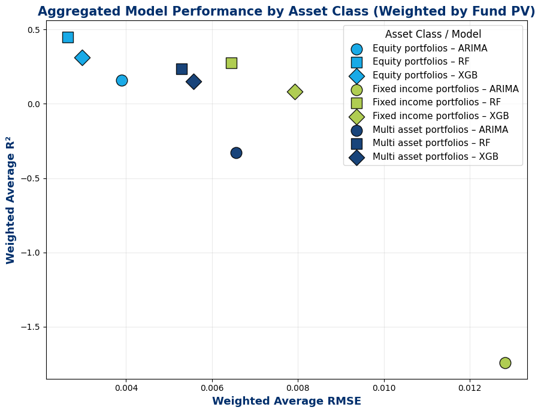

```python
# Color and marker mapping
asset_class_colors = {
   "EQ": "#00a1e5",  # Light blue for Equity
   "FI": "#A8C83F",  # Amundi green for Fixed Income
   "MA": "#002F6C"  # Amundi dark blue for Multi Asset
}
model_markers = {
   "ARIMA": "o",  # Circle
   "RF": "s",     # Square
   "XGB": "D"     # Diamond
}
# 1. Aggregate metrics by weighted average (using fund_pv_map)
agg_points = []
for asset_class in asset_class_full:
   for model in ['arima', 'rf', 'xgb']:
       # Collect all funds for this asset/model that pass the filter
       data = []
       weights = []
       for fund in filtered_funds:
           if asset_class_map.get(fund, None) == asset_class:
               metric = results[model]['metrics'][fund]['T+1']
               rmse = metric.get("RMSE", np.nan)
               r2 = metric.get("R2", np.nan)
               if np.isfinite(rmse) and np.isfinite(r2):
                   w = fund_pv_map.get(fund, 1.0)
                   data.append((rmse, r2))
                   weights.append(w)
       if data and np.sum(weights) > 0:
           data = np.array(data)
           avg_rmse = np.average(data[:, 0], weights=weights)
           avg_r2 = np.average(data[:, 1], weights=weights)
           agg_points.append({
               "Asset Class": asset_class,
               "Model": model.upper(),
               "RMSE": avg_rmse,
               "R2": avg_r2
           })
agg_df = pd.DataFrame(agg_points)
# 2. Plot the weighted average scatter
fig, ax = plt.subplots(figsize=(9, 7))
for _, row in agg_df.iterrows():
   color = asset_class_colors.get(row['Asset Class'], "#aaaaaa")
   marker = model_markers.get(row['Model'], "o")
   label = f"{asset_class_full.get(row['Asset Class'], row['Asset Class'])} – {row['Model']}"
   ax.scatter(row['RMSE'], row['R2'], color=color, marker=marker, s=180,
              edgecolor='k', label=label, alpha=0.90)
# Remove duplicate legend entries
handles, labels = ax.get_legend_handles_labels()
by_label = dict(zip(labels, handles))
ax.legend(by_label.values(), by_label.keys(), fontsize=11, title="Asset Class / Model", title_fontsize=12)
ax.set_xlabel("Weighted Average RMSE", fontsize=13, color=amundi_dark_blue, fontweight='bold')
ax.set_ylabel("Weighted Average R²", fontsize=13, color=amundi_dark_blue, fontweight='bold')
ax.set_title("Aggregated Model Performance by Asset Class (Weighted by Fund PV)",
            fontsize=15, color=amundi_dark_blue, fontweight='bold')
ax.grid(alpha=0.25)
plt.tight_layout()
plt.show()
```

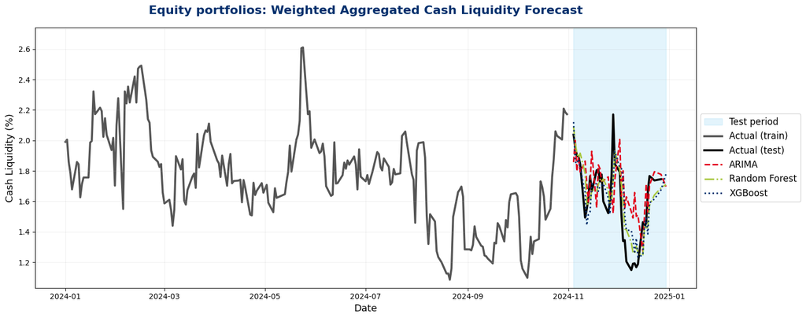

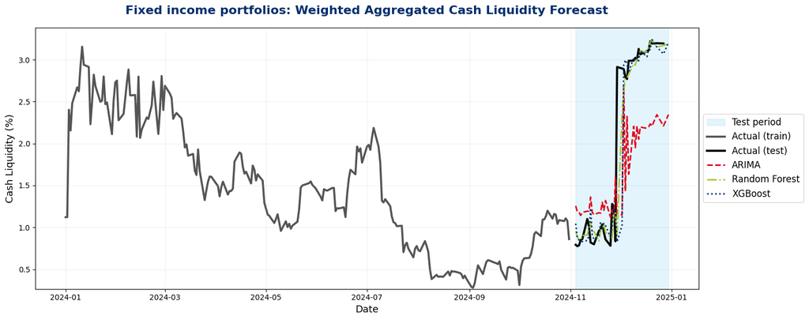

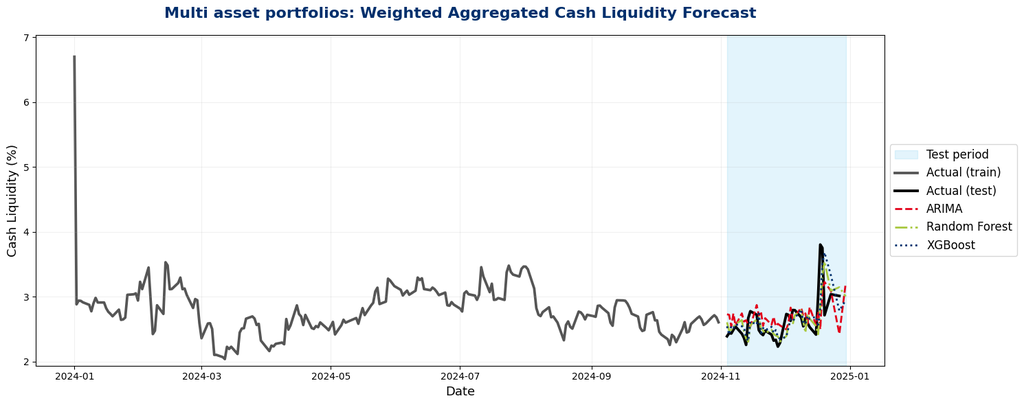

```python
# Color and marker mapping
amundi_blue = "#002F6C"
amundi_light_blue = "#00a1e5"
amundi_green = "#A8C83F"
amundi_red = "#E2001A"
test_colors = {"ARIMA": amundi_red, "RF": amundi_green, "XGB": amundi_blue}
for asset_code, full_name in asset_class_full.items():
   funds_in_class = [f for f in filtered_funds if asset_class_map.get(f, None) == asset_code]
   if not funds_in_class:
       print(f"No funds for asset class {full_name}")
       continue
   # Dates
   train_dates = set()
   test_dates = set()
   for fund in funds_in_class:
       train_dates.update(results['rf']['curves'][fund]['y_train'].index)
       test_dates.update(results['rf']['curves'][fund]['y_test'].index)
   train_dates = np.array(sorted(train_dates))
   test_dates = np.array(sorted(test_dates))
   def weighted_avg(dates, which):
       y_agg = []
       for date in dates:
           vals = []
           weights = []
           for fund in funds_in_class:
               curve = results['rf']['curves'][fund][which]
               if date in curve.index:
                   val = curve.loc[date]
                   if np.isfinite(val):
                       vals.append(val)
                       weights.append(fund_pv_map.get(fund, 1.0))
           if weights and np.sum(weights) > 0:
               y_agg.append(np.average(vals, weights=weights))
           else:
               y_agg.append(np.nan)
       return np.array(y_agg)
   agg_actual_train = weighted_avg(train_dates, 'y_train')
   agg_actual_test = weighted_avg(test_dates, 'y_test')
   def agg_model_forecast(model_key):
       pred = []
       for date in test_dates:
           vals = []
           weights = []
           for fund in funds_in_class:
               series = results[model_key]['curves'][fund]['forecast_T+1']
               if date in series.index:
                   val = series.loc[date]
                   if np.isfinite(val):
                       vals.append(val)
                       weights.append(fund_pv_map.get(fund, 1.0))
           if weights and np.sum(weights) > 0:
               pred.append(np.average(vals, weights=weights))
           else:
               pred.append(np.nan)
       return np.array(pred)
   agg_pred_arima = agg_model_forecast('arima')
   agg_pred_rf = agg_model_forecast('rf')
   agg_pred_xgb = agg_model_forecast('xgb')

   # --- PLOTTING ---
   fig, ax = plt.subplots(figsize=(15, 6))
   # Shaded test period
   if len(test_dates) > 0:
       ax.axvspan(test_dates[0], test_dates[-1], color=amundi_light_blue, alpha=0.11, label='Test period')
   # Training Actual (solid gray)
   ax.plot(train_dates, 100*agg_actual_train, color="#555555", lw=2.7, label="Actual (train)", zorder=1)
   # Test Actual (solid black)
   ax.plot(test_dates, 100*agg_actual_test, color="black", lw=2.8, label="Actual (test)", zorder=2)
   # Test Forecasts (dashed lines, thick)
   ax.plot(test_dates, 100*agg_pred_arima, color=amundi_red, lw=2, linestyle='--', label="ARIMA", zorder=3)
   ax.plot(test_dates, 100*agg_pred_rf, color=amundi_green, lw=2, linestyle='-.', label="Random Forest", zorder=4)
   ax.plot(test_dates, 100*agg_pred_xgb, color=amundi_blue, lw=2, linestyle=':', label="XGBoost", zorder=5)
   # Title, labels
   ax.set_title(f"{full_name}: Weighted Aggregated Cash Liquidity Forecast", fontsize=16, color=amundi_blue, fontweight='bold', pad=18)
   ax.set_xlabel("Date", fontsize=13)
   ax.set_ylabel("Cash Liquidity (%)", fontsize=13)
   # Tighter y-axis
   ymin = min(np.nanmin(100*agg_actual_train), np.nanmin(100*agg_actual_test)) * 0.95
   ymax = max(np.nanmax(100*agg_actual_train), np.nanmax(100*agg_actual_test)) * 1.05
   ax.set_ylim(ymin, ymax)
   # Legend outside right
   ax.legend(loc='center left', bbox_to_anchor=(1, 0.5), frameon=True, fontsize=12, title_fontsize=13)
   ax.grid(alpha=0.18)
   plt.tight_layout()
   plt.show()
```

```python
import numpy as np
import pandas as pd
import shap
import matplotlib.pyplot as plt
import matplotlib.ticker as ticker
from IPython.display import display, HTML
import ipywidgets as widgets
N = 10  # Top features
def get_friendly(feat):
   if 'make_business_friendly_name' in globals():
       return make_business_friendly_name(feat)
   return feat
def wrap_feature_name(name, maxlen=18):
   """Wrap long feature names to two lines for SHAP plots."""
   name = str(name)
   if len(name) <= maxlen:
       return name
   if ' ' in name[:maxlen]:
       idx = name.rfind(' ', 0, maxlen)
       return name[:idx] + '\n' + name[idx+1:]
   else:
       return name[:maxlen] + '\n' + name[maxlen:]
def aggregate_feature_importance(model_key):
   feat_rows = []
   for fund in filtered_funds:
       asset_class = asset_class_map.get(fund, 'Unknown')
       fi_dict = results[model_key]['feature_importances'][fund]['T+1']
       for feat, val in fi_dict.items():
           feat_rows.append({'Asset Class': asset_class, 'Feature': feat, 'Importance': val})
   df_fi = pd.DataFrame(feat_rows)
   agg_fi = df_fi.groupby(['Asset Class', 'Feature'])['Importance'].mean().reset_index()
   return agg_fi
def aggregate_shap_for_asset_class(model_key, asset_class_code):
   shap_values_all = []
   features_all = []
   for fund in filtered_funds:
       if asset_class_map.get(fund, None) != asset_class_code:
           continue
       shap_vals = results[model_key]['shap_values'][fund]['T+1']
       feat_names = results[model_key]['feature_names'][fund]['T+1']
       if shap_vals is not None and feat_names is not None:
           shap_values_all.append(shap_vals)
           features_all.append(pd.DataFrame(columns=feat_names, data=shap_vals).iloc[:, :])
   if not shap_values_all or not features_all:
       return None, None
   shap_all = np.vstack(shap_values_all)
   feature_all_names = features_all[0].columns
   mean_abs = np.abs(shap_all).mean(axis=0)
   top_idx = np.argsort(mean_abs)[::-1][:N]
   shap_top = shap_all[:, top_idx]
   feature_names_top = [feature_all_names[i] for i in top_idx]
   return shap_top, feature_names_top
# Table style with alternate row coloring
table_style = [
   {'selector': 'tbody tr:nth-child(even)', 'props': [('background-color', '#F6F6F6')]},
   {'selector': 'th', 'props': [('background-color', '#eeeeee'), ('font-size', '1.03em')]}
]
# --- Aggregate importances ---
agg_rf = aggregate_feature_importance('rf')
agg_xgb = aggregate_feature_importance('xgb')
agg_ensemble = pd.merge(
   agg_rf, agg_xgb,
   on=['Asset Class', 'Feature'],
   how='outer',
   suffixes=('_rf', '_xgb')
)
agg_ensemble[['Importance_rf', 'Importance_xgb']] = agg_ensemble[['Importance_rf', 'Importance_xgb']].fillna(0)
agg_ensemble['Ensemble Avg Importance'] = agg_ensemble[['Importance_rf', 'Importance_xgb']].mean(axis=1)
agg_ensemble['Feature Name'] = agg_ensemble['Feature'].map(get_friendly)
for aclass in sorted(set(agg_ensemble['Asset Class'])):
   full_name = asset_class_full.get(aclass, aclass)
   top_ens = agg_ensemble[agg_ensemble['Asset Class'] == aclass].sort_values(
       'Ensemble Avg Importance', ascending=False
   ).head(N)
   ens_tbl = top_ens[['Feature Name', 'Importance_rf', 'Importance_xgb', 'Ensemble Avg Importance']].rename(
       columns={
           'Feature Name': 'Feature',
           'Importance_rf': 'Random Forest Importance',
           'Importance_xgb': 'XGBoost Importance',
           'Ensemble Avg Importance': 'Ensemble Avg Importance'
       }
   ).reset_index(drop=True)
   ens_html = ens_tbl.style.set_table_styles(table_style).set_properties(**{
       'color': amundi_dark_blue,
       'background-color': 'white',
       'font-size': '0.97em'
   }).format({
       'Random Forest Importance': '{:.2%}',
       'XGBoost Importance': '{:.2%}',
       'Ensemble Avg Importance': '{:.2%}'
   }).hide(axis="index").to_html()

   table_widget = widgets.HTML(
       value=f"""
<div style='min-width:500px; max-width:600px;'>
<div style='font-weight:900; color:{amundi_dark_blue}; font-size:1.17em; text-align:left; margin-bottom:8px;'>{full_name}</div>
           {ens_html}
</div>
       """
   )
   # SHAP plots: wider, tight xlim, wrapped features, smaller fonts
   def shap_plot(model_key, title, color):
       shap_vals, feature_names = aggregate_shap_for_asset_class(model_key, aclass)
       if shap_vals is not None:
           wrapped_names = [wrap_feature_name(get_friendly(f), maxlen=18) for f in feature_names]
           fig, ax = plt.subplots(figsize=(6, 3.2))
           shap.summary_plot(
               shap_vals,
               features=None,
               feature_names=wrapped_names,
               plot_type='dot',
               show=False,
               plot_size=(5, 6)
           )
           ax = plt.gca()
           ax.set_title(title, fontsize=15, color=color, fontweight='bold', pad=14)
           ax.xaxis.set_major_locator(ticker.MaxNLocator(nbins=6))
           for label in ax.get_yticklabels():
               label.set_fontsize(8)
           for label in ax.get_xticklabels():
               label.set_fontsize(6)
           ax.ticklabel_format(style='plain', axis='x')
           abs_max = np.percentile(np.abs(shap_vals), 98)
           ax.set_xlim(-abs_max, abs_max)
           plt.tight_layout()
           widget = widgets.Output()
           with widget:
               plt.show()
           return widget
       else:
           return widgets.HTML(f"<div>No {title} SHAP data.</div>")
   rf_widget = shap_plot('rf', 'RF SHAP', amundi_dark_blue)
   xgb_widget = shap_plot('xgb', 'XGB SHAP', amundi_dark_blue)
   row = widgets.HBox(
       [table_widget, rf_widget, xgb_widget],
       layout=widgets.Layout(align_items='flex-start', gap='36px')
   )
   display(row)
```

```
HBox(children=(HTML(value='\n<div style=\'min-width:500px; max-width:600px;\'>\n<div style=\'font-weight:900; …
```

```
HBox(children=(HTML(value='\n<div style=\'min-width:500px; max-width:600px;\'>\n<div style=\'font-weight:900; …
```

```
HBox(children=(HTML(value='\n<div style=\'min-width:500px; max-width:600px;\'>\n<div style=\'font-weight:900; …
```

Equity portfolios

| Feature | Random Forest Importance | XGBoost Importance | Ensemble Avg Importance |
| --- | --- | --- | --- |
| Current Liquidity Profile CASH | 53.63% | 16.80% | 35.21% |
| Current Liquidity Profile incl. SD Ptf 1W | 8.18% | 1.35% | 4.77% |
| Liquidity Profile incl. SD Ptf 1W 1 Day Ago | 4.28% | 2.99% | 3.63% |
| 7-Day Trend in EU liquidity-absorbing factors | 0.46% | 5.70% | 3.08% |
| 7-Day Trend in EU HICP | 0.64% | 4.57% | 2.61% |
| Liquidity Profile CASH 1 Day Ago | 3.36% | 1.66% | 2.51% |
| 7-Day Volatility in SR acc | 0.21% | 3.30% | 1.75% |
| Ptf PV 1 Day Ago | 0.22% | 1.67% | 0.95% |
| Change in Liquidity Profile incl. SD Ptf 1Y Since 7 Days Ago | 0.38% | 1.30% | 0.84% |
| 7-Day Trend in Liquidity Profile incl. SD Ptf 1S | 0.66% | 0.98% | 0.82% |

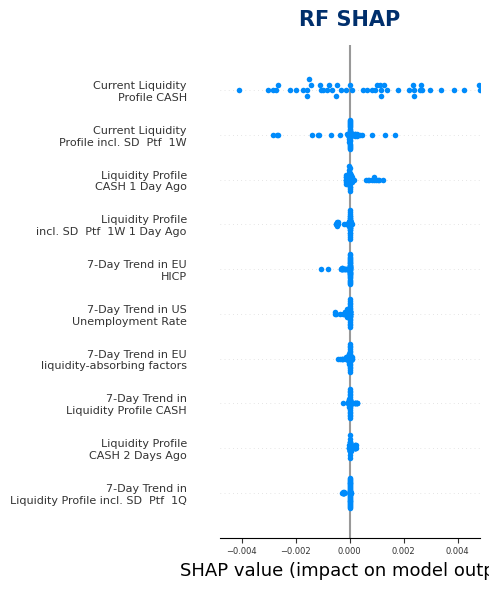

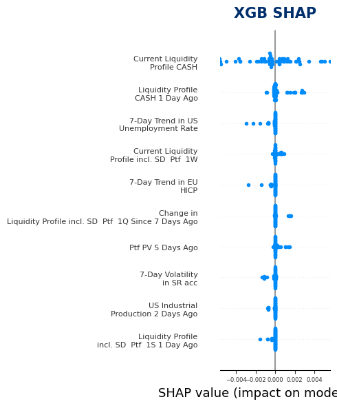

Fixed income portfolios

| Feature | Random Forest Importance | XGBoost Importance | Ensemble Avg Importance |
| --- | --- | --- | --- |
| Current Liquidity Profile CASH | 37.58% | 16.32% | 26.95% |
| Current Liquidity Profile incl. SD Ptf 1W | 18.27% | 8.32% | 13.29% |
| 7-Day Trend in US CPI | 1.65% | 14.14% | 7.89% |
| 7-Day Trend in Liquidity Profile CASH | 4.74% | 7.01% | 5.88% |
| UCITS - Commitment 2 Days Ago | 0.80% | 4.19% | 2.50% |
| US CPI 2 Days Ago | 1.29% | 3.05% | 2.17% |
| 7-Day Trend in Liquidity Profile incl. SD Ptf 1W | 2.69% | 0.77% | 1.73% |
| US CPI 5 Days Ago | 0.07% | 2.14% | 1.10% |
| 7-Day Trend in US GDP | 1.74% | 0.00% | 0.87% |
| 7-Day Trend in US Retail Sales | 1.56% | 0.09% | 0.82% |

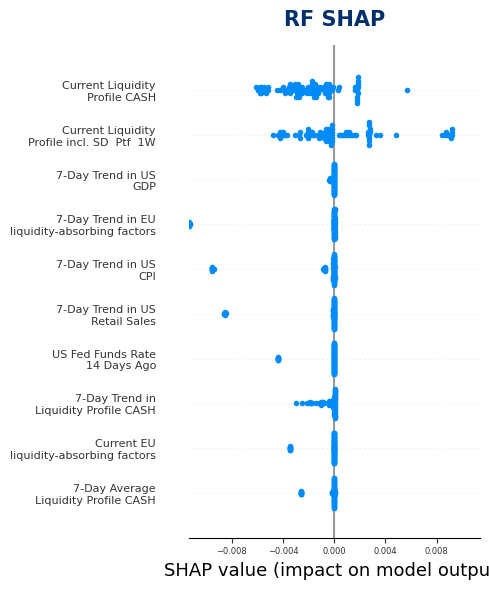

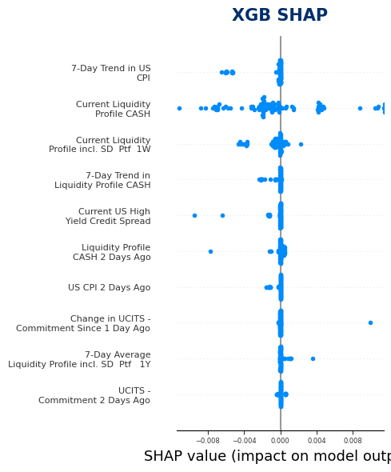

Multi asset portfolios

| Feature | Random Forest Importance | XGBoost Importance | Ensemble Avg Importance |
| --- | --- | --- | --- |
| Current Liquidity Profile CASH | 41.19% | 11.31% | 26.25% |
| 7-Day Trend in Liquidity Profile CASH | 9.00% | 13.30% | 11.15% |
| Current Liquidity Profile incl. SD Ptf 1W | 9.72% | 2.37% | 6.05% |
| 7-Day Trend in US CPI | 1.95% | 6.81% | 4.38% |
| 7-Day Trend in SR acc | 1.60% | 5.83% | 3.71% |
| Liquidity Profile CASH 1 Day Ago | 2.52% | 1.21% | 1.87% |
| 7-Day Trend in UCITS - Commitment | 1.01% | 1.02% | 1.01% |
| 7-Day Average US CPI | 0.10% | 1.75% | 0.92% |
| 7-Day Trend in US Consumer Confidence | 0.89% | 0.83% | 0.86% |
| 7-Day Trend in EU interest rate | 1.49% | 0.00% | 0.74% |

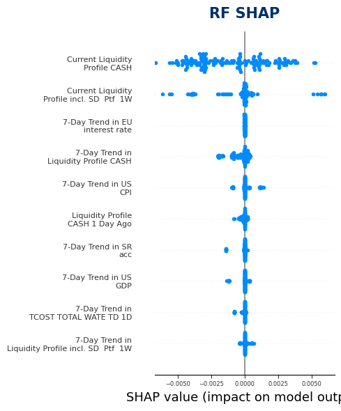

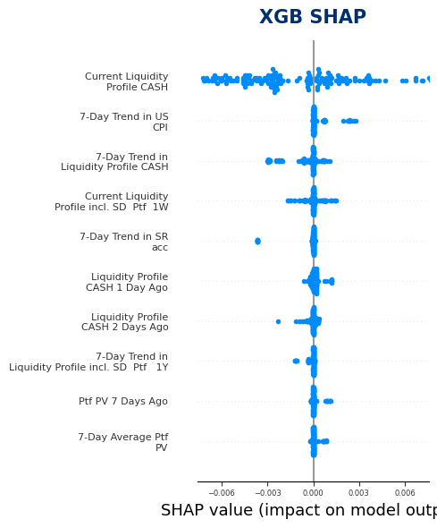

```python
import numpy as np
import pandas as pd
import shap
import matplotlib.pyplot as plt
import matplotlib.ticker as ticker
from IPython.display import display, HTML
N = 10  # Top features
def get_friendly(feat):
   if 'make_business_friendly_name' in globals():
       return make_business_friendly_name(feat)
   return feat
def wrap_feature_name(name, maxlen=18):
   """Wrap long feature names to two lines for SHAP plots."""
   name = str(name)
   if len(name) <= maxlen:
       return name
   if ' ' in name[:maxlen]:
       idx = name.rfind(' ', 0, maxlen)
       return name[:idx] + '\n' + name[idx+1:]
   else:
       return name[:maxlen] + '\n' + name[maxlen:]
def aggregate_feature_importance(model_key):
   feat_rows = []
   for fund in filtered_funds:
       asset_class = asset_class_map.get(fund, 'Unknown')
       fi_dict = results[model_key]['feature_importances'][fund]['T+1']
       for feat, val in fi_dict.items():
           feat_rows.append({'Asset Class': asset_class, 'Feature': feat, 'Importance': val})
   df_fi = pd.DataFrame(feat_rows)
   agg_fi = df_fi.groupby(['Asset Class', 'Feature'])['Importance'].mean().reset_index()
   return agg_fi
def aggregate_shap_for_asset_class(model_key, asset_class_code):
   shap_values_all = []
   features_all = []
   for fund in filtered_funds:
       if asset_class_map.get(fund, None) != asset_class_code:
           continue
       shap_vals = results[model_key]['shap_values'][fund]['T+1']
       feat_names = results[model_key]['feature_names'][fund]['T+1']
       if shap_vals is not None and feat_names is not None:
           shap_values_all.append(shap_vals)
           features_all.append(pd.DataFrame(columns=feat_names, data=shap_vals).iloc[:, :])
   if not shap_values_all or not features_all:
       return None, None
   shap_all = np.vstack(shap_values_all)
   feature_all_names = features_all[0].columns
   mean_abs = np.abs(shap_all).mean(axis=0)
   top_idx = np.argsort(mean_abs)[::-1][:N]
   shap_top = shap_all[:, top_idx]
   feature_names_top = [feature_all_names[i] for i in top_idx]
   return shap_top, feature_names_top
# Table style with alternate row coloring
table_style = [
   {'selector': 'tbody tr:nth-child(even)', 'props': [('background-color', '#F6F6F6')]},
   {'selector': 'th', 'props': [('background-color', '#eeeeee'), ('font-size', '1.03em')]}
]
# --- Aggregate importances ---
agg_rf = aggregate_feature_importance('rf')
agg_xgb = aggregate_feature_importance('xgb')
agg_ensemble = pd.merge(
   agg_rf, agg_xgb,
   on=['Asset Class', 'Feature'],
   how='outer',
   suffixes=('_rf', '_xgb')
)
agg_ensemble[['Importance_rf', 'Importance_xgb']] = agg_ensemble[['Importance_rf', 'Importance_xgb']].fillna(0)
agg_ensemble['Ensemble Avg Importance'] = agg_ensemble[['Importance_rf', 'Importance_xgb']].mean(axis=1)
agg_ensemble['Feature Name'] = agg_ensemble['Feature'].map(get_friendly)
for aclass in sorted(set(agg_ensemble['Asset Class'])):
   full_name = asset_class_full.get(aclass, aclass)
   top_ens = agg_ensemble[agg_ensemble['Asset Class'] == aclass].sort_values(
       'Ensemble Avg Importance', ascending=False
   ).head(N)
   ens_tbl = top_ens[['Feature Name', 'Importance_rf', 'Importance_xgb', 'Ensemble Avg Importance']].rename(
       columns={
           'Feature Name': 'Feature',
           'Importance_rf': 'Random Forest Importance',
           'Importance_xgb': 'XGBoost Importance',
           'Ensemble Avg Importance': 'Ensemble Avg Importance'
       }
   ).reset_index(drop=True)
   ens_html = ens_tbl.style.set_table_styles(table_style).set_properties(**{
       'color': amundi_dark_blue,
       'background-color': 'white',
       'font-size': '0.97em'
   }).format({
       'Random Forest Importance': '{:.2%}',
       'XGBoost Importance': '{:.2%}',
       'Ensemble Avg Importance': '{:.2%}'
   }).hide(axis="index").to_html()
   # ---- STATIC DISPLAY: TABLE + SHAP PLOTS ----
   display(HTML(
       f"""
<div style='min-width:500px; max-width:600px;'>
<div style='font-weight:900; color:{amundi_dark_blue}; font-size:1.17em; text-align:left; margin-bottom:8px;'>
               {full_name}
</div>
           {ens_html}
</div>
       """
   ))
   # --- STATIC SHAP PLOTS ---
   def shap_plot(model_key, title, color):
       shap_vals, feature_names = aggregate_shap_for_asset_class(model_key, aclass)
       if shap_vals is not None:
           wrapped_names = [wrap_feature_name(get_friendly(f), maxlen=18) for f in feature_names]
           fig, ax = plt.subplots(figsize=(6, 3.2))
           shap.summary_plot(
               shap_vals,
               features=None,
               feature_names=wrapped_names,
               plot_type='dot',
               show=False,
               plot_size=(5, 6)
           )
           ax = plt.gca()
           ax.set_title(title, fontsize=15, color=color, fontweight='bold', pad=14)
           ax.xaxis.set_major_locator(ticker.MaxNLocator(nbins=6))
           for label in ax.get_yticklabels():
               label.set_fontsize(8)
           for label in ax.get_xticklabels():
               label.set_fontsize(6)
           ax.ticklabel_format(style='plain', axis='x')
           abs_max = np.percentile(np.abs(shap_vals), 98)
           ax.set_xlim(-abs_max, abs_max)
           plt.tight_layout()
           plt.show()
       else:
           display(HTML(f"<div style='color:red; margin-top:6px; margin-bottom:12px'><b>No {title} SHAP data.</b></div>"))
   shap_plot('rf', 'RF SHAP', amundi_dark_blue)
   shap_plot('xgb', 'XGB SHAP', amundi_dark_blue)
```

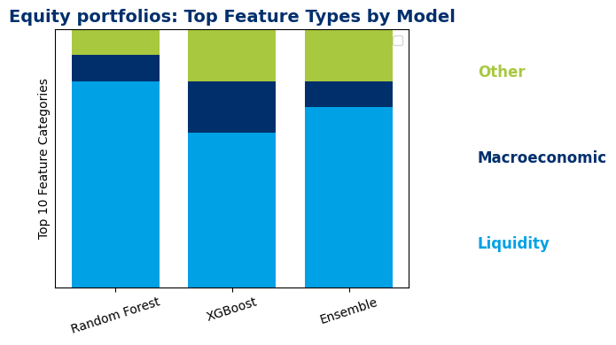

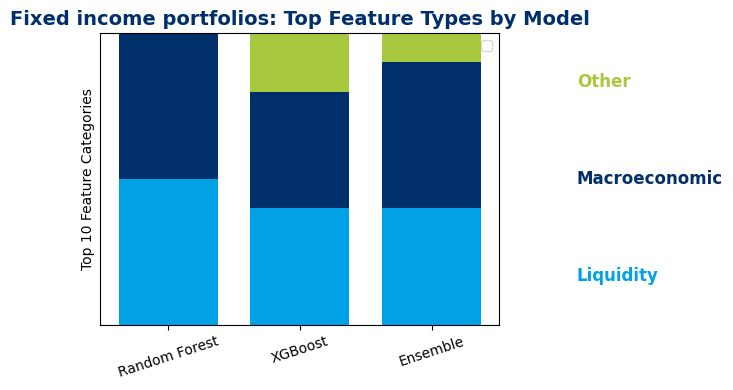

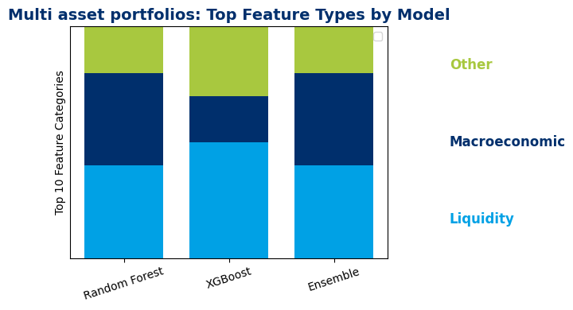

```python
import matplotlib.pyplot as plt
import numpy as np
category_colors = {
   "Liquidity Indicator": "#00a1e5",
   "Macroeconomic Indicator": "#002F6C",
   "Other": "#A8C83F"
}
category_order = ["Liquidity Indicator", "Macroeconomic Indicator", "Other"]
plot_df = df_summary.copy()
plot_df = plot_df.set_index(['Asset Class', 'Model'])
plot_df = plot_df.rename(columns={
   "Liquidity (%)": "Liquidity Indicator",
   "Macroeconomic (%)": "Macroeconomic Indicator",
   "Other (%)": "Other"
})
asset_classes = plot_df.index.get_level_values(0).unique()
models = plot_df.index.get_level_values(1).unique()
for aclass in asset_classes:
   sub = plot_df.loc[aclass]
   x = np.arange(len(sub))  # one per model
   width = 0.75
   fig, ax = plt.subplots(figsize=(7, 4))
   bottoms = np.zeros(len(sub))
   for cat in category_order:
       values = sub[cat].values
       ax.bar(x, values, width, bottom=bottoms, color=category_colors[cat])
       bottoms += values
   ax.set_xticks(x)
   ax.set_xticklabels(sub.index, rotation=18)
   ax.set_ylim(0, 100)
   ax.set_ylabel("Top 10 Feature Categories")
   ax.set_yticks([])  # No y axis numbers
   ax.set_title(f"{aclass}: Top Feature Types by Model", color=amundi_dark_blue, fontsize=14, fontweight='bold')
   ax.legend(loc="upper right", frameon=True)
   ax.grid(False)
   # Write the category names directly on the right side of the chart
   for i, cat in enumerate(category_order):
       ax.text(len(sub) + 0.1, (i + 0.5) * 100 / len(category_order),
               cat.replace(" Indicator", ""), color=category_colors[cat],
               fontsize=12, fontweight='bold', va='center')
   plt.tight_layout()
   plt.show()
```

# V. Model_Distillation

In this section, we focus on the distillation of model predictions for cash liquidity forecasting using the top-performing features from Random Forest (RF), XGBoost (XGB), and an ensemble approach. The goal is to create simplified models that retain the predictive power of the original complex models while being easier to interpret and deploy.

## Structure Initialization

We begin by ensuring that the necessary structures for storing the distillate results are created if they do not already exist. This includes separate entries for distillate models based on RF, XGB, and an ensemble of both.

## Feature Selection

A helper function is defined to retrieve the top features for each model type. The distillation process involves iterating through each asset class and selecting the relevant features for the models. For each fund within the asset class, we prepare the data by:

1. **Data Preparation**:
   - Extracting the time series data for the "Liquidity Profile CASH".
   - Creating lagged features and imputing missing values.
   - Defining the target variable for prediction.
2. **Model Training**:
   - A linear regression model is trained on the cleaned training data.
   - Predictions are made on the test set, and the results are stored in the appropriate structure for later analysis.

## Aggregated Predictions

After training the models, we aggregate the predictions for each asset class. This involves calculating weighted averages of the predictions based on the fund's present value (PV) to ensure that larger funds have a proportionally greater impact on the aggregated results.

## Visualization

Finally, we visualize the distillate model predictions against the actual cash liquidity values for each asset class. The plots include:

- **Actual Values**: Displayed for both training and testing periods.
- **Model Predictions**: Shown for each distillate model, allowing for a clear comparison of performance.

This distillation process not only simplifies the models but also provides insights into the predictive capabilities of the selected features, enhancing interpretability and usability in real-world applications.

```python
# Create the structures if not already present
for d_key in ['distillate_rf', 'distillate_xgb', 'distillate_ensemble']:
   if d_key not in results:
       results[d_key] = {'curves': {}}
# Helper to get the right top features per model type
def get_distillate_features_dict(model_type):
   if model_type == 'distillate_rf':
       return top_rf_features
   elif model_type == 'distillate_xgb':
       return top_xgb_features
   elif model_type == 'distillate_ensemble':
       return top_ensemble_features
for model_type in ['distillate_rf', 'distillate_xgb', 'distillate_ensemble']:
   top_features_dict = get_distillate_features_dict(model_type)
   for asset_class in top_features_dict:
       features = top_features_dict[asset_class]
       funds_in_class = [f for f in filtered_funds if asset_class_map.get(f, None) == asset_class]
       for fund_name in funds_in_class:
           fund_id = build_fund_name_map(cleaned_data).get(fund_name, None)
           if fund_id is None or fund_id not in cleaned_data:
               continue
           df = cleaned_data[fund_id].copy()
           if "DATE_C" not in df or "Liquidity Profile CASH" not in df:
               continue
           df["DATE_C"] = pd.to_datetime(df["DATE_C"], errors="coerce")
           df.set_index("DATE_C", inplace=True)
           ts = df["Liquidity Profile CASH"]["2024-01-01":"2024-12-31"].dropna()
           if len(ts) < 30:
               continue
           train = ts["2024-01-01":"2024-10-31"]
           test = ts["2024-11-01":"2024-12-31"]
           all_features_raw = [col for col in df.columns if any(
               k in col for k in [
                   "Liquidity Profile", "PV", "EU", "US", "SR acc", "VAR", "CVAR", "TCOST_", "UCITS - Commitment"
               ]
           )]
           df_feat = extended_lag_features(df[all_features_raw], all_features_raw)
           df_feat = impute_with_special_forward_rolling_mean(df_feat)
           df_feat["target"] = ts.shift(-1)
           df_feat.columns = sanitize_feature_names(df_feat.columns)
           available_features = [f for f in features if f in df_feat.columns]
           train_df, test_df = df_feat.loc[train.index], df_feat.loc[test.index]
           train_X, test_X = train_df[available_features], test_df[available_features]
           train_y, test_y = train_df["target"], test_df["target"]
           train_mask = train_X.notnull().all(axis=1) & train_y.notnull()
           test_mask = test_X.notnull().all(axis=1) & test_y.notnull()
           train_X_clean, train_y_clean = train_X[train_mask], train_y[train_mask]
           test_X_clean, test_y_clean = test_X[test_mask], test_y[test_mask]
           if train_X_clean.shape[0] == 0 or test_X_clean.shape[0] == 0:
               continue
           model = LinearRegression()
           model.fit(train_X_clean, train_y_clean)
           preds = model.predict(test_X_clean)
           # Save in the expected results structure for plotting
           if fund_name not in results[model_type]['curves']:
               results[model_type]['curves'][fund_name] = {}
           results[model_type]['curves'][fund_name]['forecast_T+1'] = pd.Series(preds, index=test_X_clean.index)
           results[model_type]['curves'][fund_name]['y_test'] = test_y_clean  # optionally store actuals too

# After this, these variables will work for plotting:
distillate_rf_curves = results['distillate_rf']['curves']
distillate_xgb_curves = results['distillate_xgb']['curves']
distillate_ensemble_curves = results['distillate_ensemble']['curves']
```

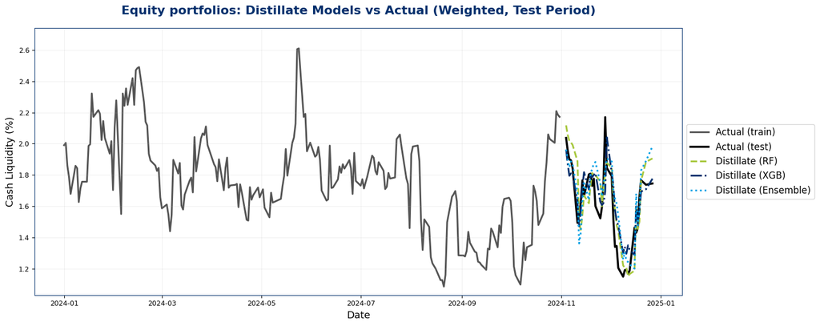

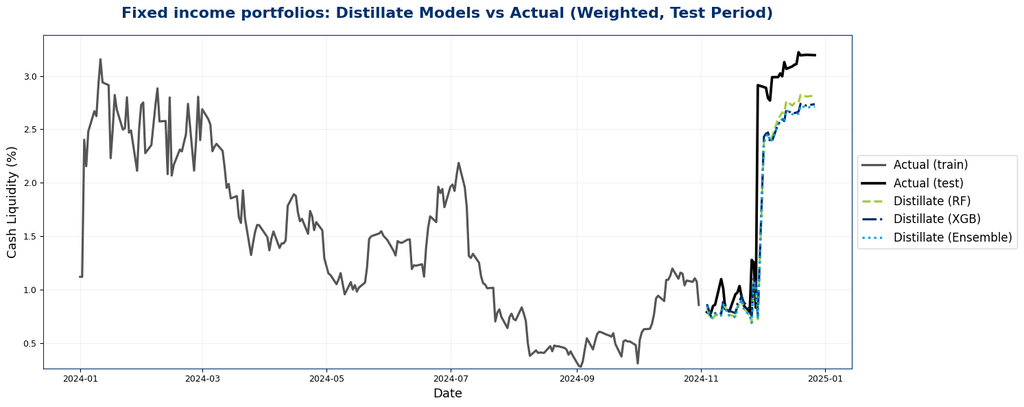

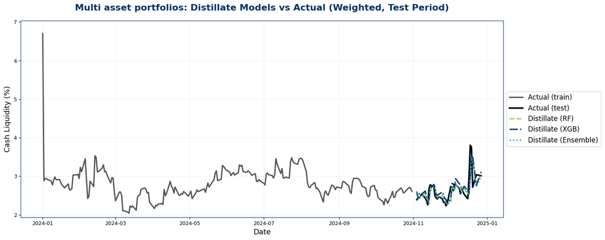

```python
# ---- Styling and config ----
distillate_colors = {
   'DISTILLATE_RF': "#A8C83F",         # green
   'DISTILLATE_XGB': "#002F6C",        # dark blue
   'DISTILLATE_ENSEMBLE': "#00a1e5"    # light blue
}
distillate_labels = {
   'DISTILLATE_RF': "Distillate (RF)",
   'DISTILLATE_XGB': "Distillate (XGB)",
   'DISTILLATE_ENSEMBLE': "Distillate (Ensemble)"
}
distillate_curves_dicts = {
   "DISTILLATE_RF": distillate_rf_curves,
   "DISTILLATE_XGB": distillate_xgb_curves,
   "DISTILLATE_ENSEMBLE": distillate_ensemble_curves
}
for asset_code, full_name in asset_class_full.items():
   funds_in_class = [f for f in filtered_funds if asset_class_map.get(f, None) == asset_code]
   if not funds_in_class:
       print(f"No funds for asset class {full_name}")
       continue
   # Collect train/test dates as before
   train_dates = set()
   test_dates = set()
   for fund in funds_in_class:
       train_dates.update(results['rf']['curves'][fund]['y_train'].index)
       test_dates.update(results['rf']['curves'][fund]['y_test'].index)
   train_dates = np.array(sorted(train_dates))
   test_dates = np.array(sorted(test_dates))
   def weighted_avg(dates, which):
       y_agg = []
       for date in dates:
           vals = []
           weights = []
           for fund in funds_in_class:
               curve = results['rf']['curves'][fund][which]
               if date in curve.index:
                   val = curve.loc[date]
                   if np.isfinite(val):
                       vals.append(val)
                       weights.append(fund_pv_map.get(fund, 1.0))
           if weights and np.sum(weights) > 0:
               y_agg.append(np.average(vals, weights=weights))
           else:
               y_agg.append(np.nan)
       return np.array(y_agg)
   agg_actual_train = weighted_avg(train_dates, 'y_train')
   agg_actual_test = weighted_avg(test_dates, 'y_test')
   def agg_distillate_forecast(model_curves_dict):
       pred = []
       for date in test_dates:
           vals = []
           weights = []
           for fund in funds_in_class:
               if fund in model_curves_dict and 'forecast_T+1' in model_curves_dict[fund]:
                   series = model_curves_dict[fund]['forecast_T+1']
                   if date in series.index:
                       val = series.loc[date]
                       if np.isfinite(val):
                           vals.append(val)
                           weights.append(fund_pv_map.get(fund, 1.0))
           if weights and np.sum(weights) > 0:
               pred.append(np.average(vals, weights=weights))
           else:
               pred.append(np.nan)
       return np.array(pred)

   # --- PLOTTING ---
   fig, ax = plt.subplots(figsize=(15, 6))
   # Training Actual (solid gray)
   ax.plot(train_dates, 100*agg_actual_train, color="#555555", lw=2.3, label="Actual (train)", zorder=1)
   # Test Actual (solid black)
   ax.plot(test_dates, 100*agg_actual_test, color="black", lw=2.7, label="Actual (test)", zorder=2)
   for model_key in ["DISTILLATE_RF", "DISTILLATE_XGB", "DISTILLATE_ENSEMBLE"]:
       if model_key in distillate_curves_dicts:
           agg_pred = agg_distillate_forecast(distillate_curves_dicts[model_key])
           linestyle = "--" if model_key == "DISTILLATE_RF" else "-." if model_key == "DISTILLATE_XGB" else ":"
           ax.plot(test_dates, 100*agg_pred, color=distillate_colors[model_key],
                   lw=2.3, linestyle=linestyle, label=distillate_labels[model_key])

   # Title, labels
   ax.set_title(f"{full_name}: Distillate Models vs Actual (Weighted, Test Period)", fontsize=16, color=amundi_dark_blue, fontweight='bold', pad=18)
   ax.set_xlabel("Date", fontsize=13)
   ax.set_ylabel("Cash Liquidity (%)", fontsize=13)
   ymin = min(np.nanmin(100*agg_actual_train), np.nanmin(100*agg_actual_test)) * 0.95
   ymax = max(np.nanmax(100*agg_actual_train), np.nanmax(100*agg_actual_test)) * 1.05
   ax.set_ylim(ymin, ymax)
   ax.legend(loc='center left', bbox_to_anchor=(1, 0.5), frameon=True, fontsize=12, title_fontsize=13)
   ax.grid(alpha=0.18)
   plt.tight_layout()
   plt.show()
```